# Probability Basics

TEMBA Statistics 2026

## Random variables

**Definition: Random variable**

A **random variable** is a number about which we are uncertain, either because we have incomplete information or because it depends on what happens in the future. We write random variables as capital letters: $X$, $Y$, and $D$.

- Let $D=1$ if a new loan defaults and $D=0$ if it is repaid.
- Let $X$ be the loan’s payoff in dollars.
- Uncertain categories become random variables by coding, just as observed categories did.

## Events and probability

- An **event** is a collection of possible outcomes. Examples include “the loan defaults” ($D = 1$) and “the payoff is at least $10,000” ($X \geq 10{,}000$).
- A **probability** is a number in $[0, 1]$ attached to an event — the higher the number, the more likely the event.

## The three fundamental probability rules

1. **Probabilities are non-negative.** $\Pr(A) \geq 0$.
2. **Something must happen.** $\Pr(\text{all possible outcomes}) = 1$.
3. **Mutually exclusive events add.** If $A$ and $B$ can’t both happen, $\Pr(A \text{ or } B) = \Pr(A) + \Pr(B)$.

Everything else we do with probabilities follows from these three rules.

## Complement and addition rules

The **complement rule**:

$$\Pr(\text{not } A) = 1 - \Pr(A)$$

The **addition rule**, when events can overlap:

$$\Pr(A \text{ or } B) = \Pr(A) + \Pr(B) - \Pr(A \text{ and } B)$$

We subtract the overlap because it got counted twice.

## Overlapping and mutually exclusive events

For one e-commerce order,

$$\Pr(\text{return})=0.18,\quad
\Pr(\text{contact})=0.24,\quad
\Pr(\text{both})=0.09.$$

What is the probability that the order is returned or produces a customer-service contact?

$$0.18+0.24-0.09=0.33.$$

A separate order must use exactly one of two methods: standard with probability 0.68 or express with probability 0.32. These events cannot overlap, so their union has probability $0.68+0.32=1$.

## Discrete and continuous random variables

- A **discrete** random variable takes specific, distinct values that we can list. Examples include $D$, $X$, and counts.
- A **continuous** random variable can take any value in a range. Examples include prices and returns.
- The distinction differs from quantitative versus categorical: a count is quantitative but discrete.

## The distribution of the default indicator

| Outcome | Meaning | Probability |
| --- | --- | --- |
| $D = 1$ | Loan defaults | 0.25 |
| $D = 0$ | Loan is repaid | 0.75 |

**Definition: Probability mass function**

A **PMF** assigns a probability to each possible outcome of a discrete random variable. The probabilities are non-negative and sum to one. This is the probability-model analogue of the proportion column in a frequency table.

## Complete a support-ticket PMF

$X$ is the number of times a support ticket is escalated. What height completes its PMF?

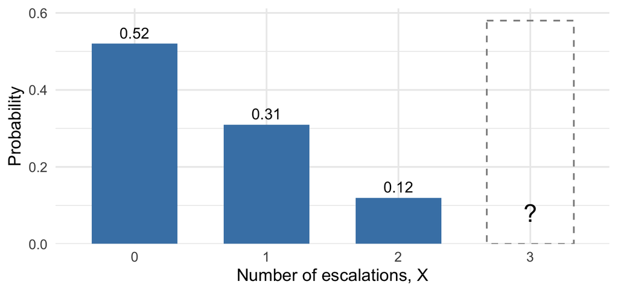

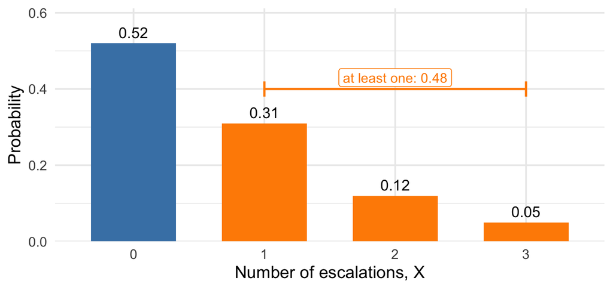

## The loan payoff distribution

This distribution describes a $10,000 loan at 12% interest, with 60% of principal recovered in default.

| Outcome | Meaning | Probability |
| --- | --- | --- |
| $X = \$11{,}200$ | Loan is repaid (principal + interest) | 0.75 |
| $X = \$6{,}000$ | Loan defaults (60% of principal recovered) | 0.25 |

Because the outcomes are now dollar amounts, we can ask what payoff the lender should *expect*.

## The FedWatch distributions as bar charts

The [CME FedWatch](https://www.cmegroup.com/markets/interest-rates/cme-fedwatch-tool.html) distributions recorded on July 9, 2026 are discrete PMFs.

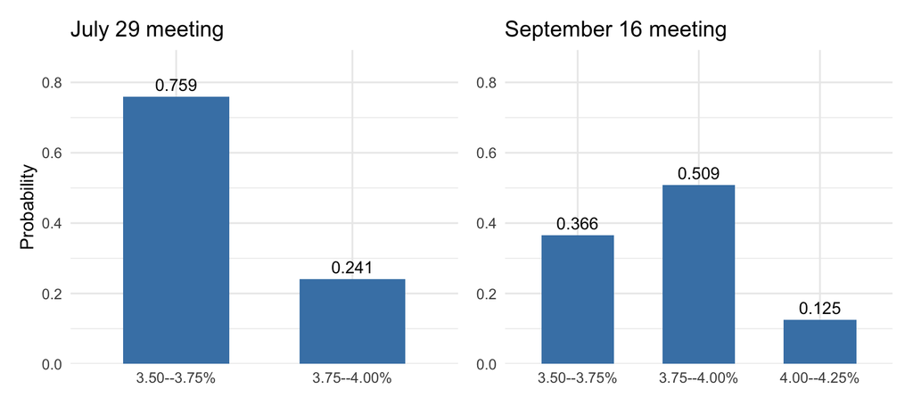

Unlike a distribution of observed data, these heights are probabilities for outcomes that have not happened yet.

## Probability density functions

**Definition: Probability density function**

A **PDF** assigns probabilities to **intervals** of a continuous random variable: the probability of an interval is the area under the curve over it. The curve is never negative, and the total area is one.

- The height of the curve is *not* a probability — only areas are.
- Any single exact value has probability zero.

## A price model for a future sale

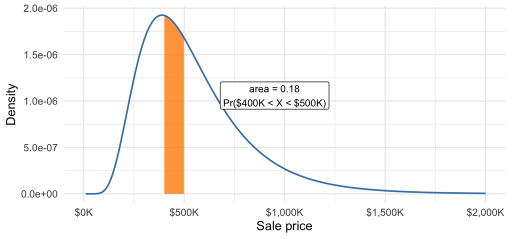

This probability model is anchored on the historical prices. Under the model, the next sale price $X$ lands between $400K and $500K with probability 0.18.

## The cumulative distribution function

The **CDF** plots the accumulated probability $\Pr(X \leq x)$ against the price threshold $x$.

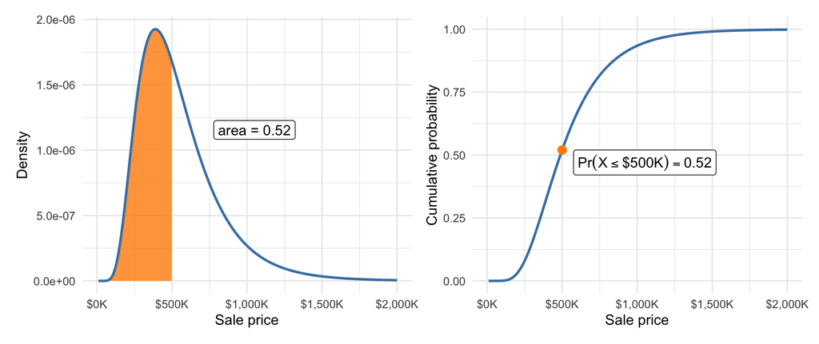

The marked point on the right equals the shaded area on the left. The CDF rises fastest where the density places the most probability.

## Build the support-ticket CDF

Accumulate the PMF bar heights from left to right. Where does the CDF show $\Pr(X\leq 1)$? How does its jump at 2 recover $\Pr(X=2)$?

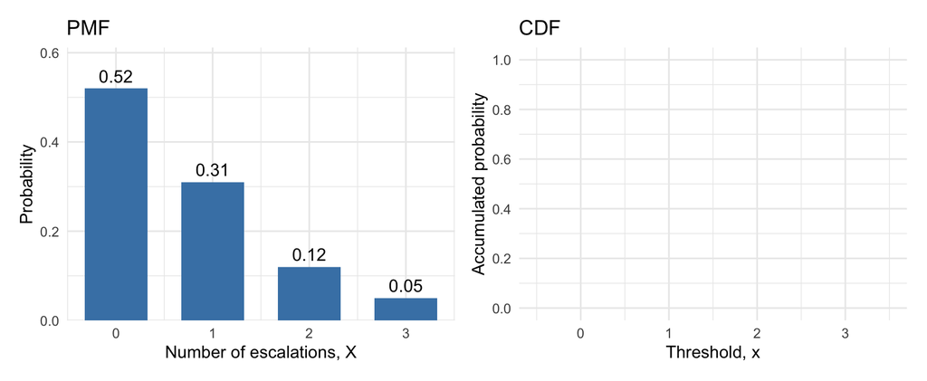

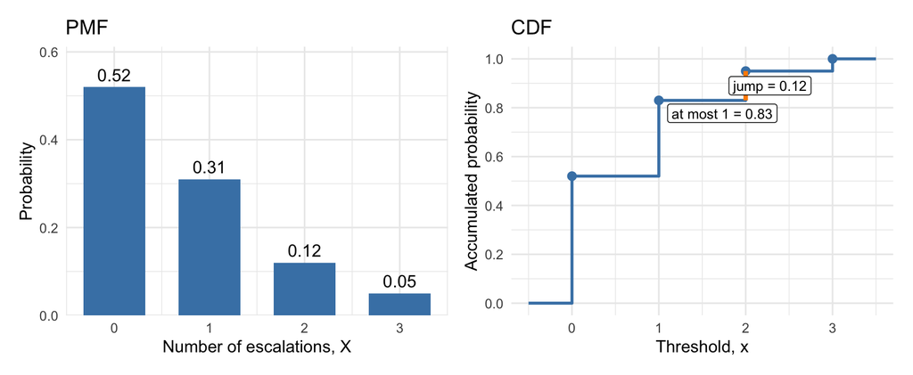

## Tracing out the CDF

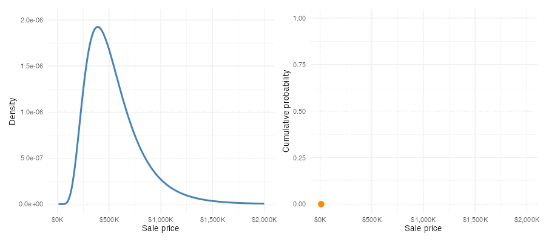